# Practical Machine Learning - Course Project

Shwetank Dwivedi

7/6/2020

### Motto :

A group of enthusiasts who take measurements about themselves regularly to improve their health, to find patterns in their behavior, were asked to perform barbell lifts correctly and incorrectly in 5 different ways.The goal of this project is to predict the manner in which they did the exercise by using data from accelerometers on the belt, forearm, arm, and dumbell of 6 participants. . This is the “classe” variable in the training set. We will create a report describing how we built our model.We will also use our prediction model to predict 20 different test cases.

### Dataset :

The training data for this project are available here: [link](https://d396qusza40orc.cloudfront.net/predmachlearn/pml-training.csv) The test data are available here: [link](https://d396qusza40orc.cloudfront.net/predmachlearn/pml-testing.csv) The data for this project come from this source: [link](http://web.archive.org/web/20161224072740/http:/groupware.les.inf.puc-rio.br/har.)

#### I would like to pay my sincere gratitude towards the authors of the above DataSet for their generosity in allowing the data to be analysed for the purpose of this project.

#### 1) libraries used :

```r
library(caret)
library (rpart)
library(randomForest)
library (rpart.plot)
library (corrplot)
library(knitr)
library(rattle)
```

#### 2) Downloading the Data from the URL

```r
training = read.csv( url ('https://d396qusza40orc.cloudfront.net/predmachlearn/pml-training.csv') , na.strings = c ("NA","") )

testing = read.csv( url ('https://d396qusza40orc.cloudfront.net/predmachlearn/pml-testing.csv'), na.strings = c ("NA","") )
```

#### 3) Partitioning the training data into 70% training and 30% testing

```r
set.seed (3434)

inTrain  = createDataPartition (training$classe , p =0.7 , list = FALSE)

TrainSet = training [inTrain ,]

TestSet  = training [ -inTrain ,]

dim(TrainSet)
```

```
## [1] 13737   160
```

```r
dim(TestSet)
```

```
## [1] 5885  160
```

#### 4) Data Cleaning

```r
NZV = nearZeroVar(TrainSet)

TrainSet = TrainSet[, -NZV]

TestSet  = TestSet[, -NZV]

NAElements = sapply( TrainSet , function(x) mean(is.na(x))  ) > 0.95

TrainSet = TrainSet [, NAElements == FALSE]

TestSet  = TestSet  [, NAElements == FALSE]

dim(TrainSet)
```

```
## [1] 13737    59
```

```r
dim(TestSet)
```

```
## [1] 5885   59
```

The first five variables do not help in out target prediction as they are merely observation identifiers.

```r
head(TrainSet)
```

```
##     X user_name raw_timestamp_part_1 raw_timestamp_part_2   cvtd_timestamp
## 1   1  carlitos           1323084231               788290 05/12/2011 11:23
## 3   3  carlitos           1323084231               820366 05/12/2011 11:23
## 6   6  carlitos           1323084232               304277 05/12/2011 11:23
## 7   7  carlitos           1323084232               368296 05/12/2011 11:23
## 9   9  carlitos           1323084232               484323 05/12/2011 11:23
## 11 11  carlitos           1323084232               500302 05/12/2011 11:23
##    num_window roll_belt pitch_belt yaw_belt total_accel_belt gyros_belt_x
## 1          11      1.41       8.07    -94.4                3         0.00
## 3          11      1.42       8.07    -94.4                3         0.00
## 6          12      1.45       8.06    -94.4                3         0.02
## 7          12      1.42       8.09    -94.4                3         0.02
## 9          12      1.43       8.16    -94.4                3         0.02
## 11         12      1.45       8.18    -94.4                3         0.03
##    gyros_belt_y gyros_belt_z accel_belt_x accel_belt_y accel_belt_z
```

[output cut: 69 more lines]

So we can remove them from our training and testing dataset and be left with 54 variables.

```r
TrainSet = TrainSet [ , - (1:5)]

TestSet = TestSet [ , - (1:5)]

dim(TrainSet)
```

```
## [1] 13737    54
```

```r
dim(TestSet)
```

```
## [1] 5885   54
```

#### 5) Preprocessing Analysis

Now we can see if our predictors are highly corelated ( after removing classe variable) so that some of them could be clubbed using PCA and that would help us decrease the no. of total predictors.

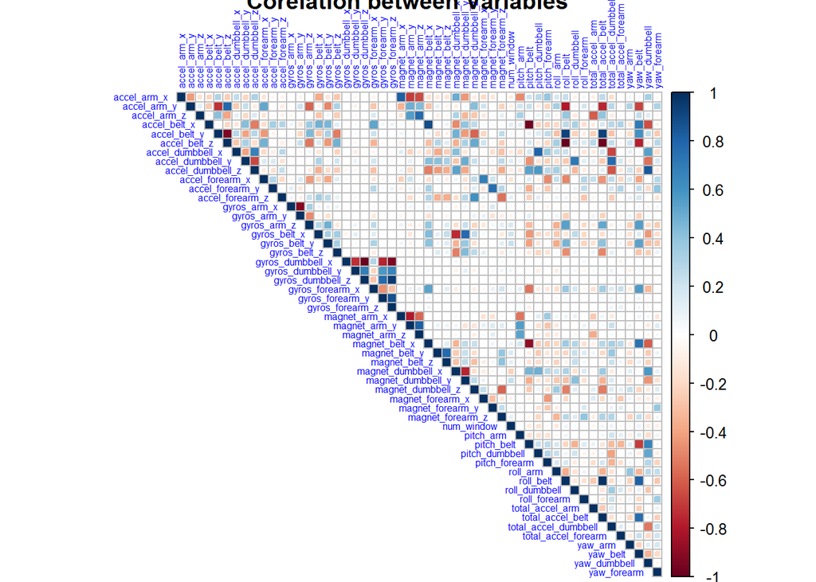

```r
coranalysis = cor (TrainSet [,-54])

corrplot(coranalysis , order = "alphabet", method = "square", type = "upper",title = "Corelation between Variables" , bg = "white", tl.cex = 0.5 , tl.col = rgb (0,0,1))
```

The dark blue color blocks in the triangular area of the above graph denote high corelation which are very few and far between so there isn’t much corelation among predictors so as to apply PCA on them.

#### 6) Model Building

Now we can build two models – 1) Random Forest 2) Decision Trees on the train dataset and the model with best accuracy acquired through Confusion Matrix will be applied to the test dataset.

> 1. Random Forest

For Sampling , I have used k-fold cross-validation with 5 folds to estimate the prediction error rate it balances the bias-variance trade off very well given the data we have.

```r
set.seed(4459)
trcontrolCV = trainControl( method = "cv", number = 5, verboseIter=FALSE )
modFitRF = train (classe ~., data = TrainSet, method = "rf", trControl = trcontrolCV )
modFitRF$finalModel
```

```
##
## Call:
##  randomForest(x = x, y = y, mtry = param$mtry)
##                Type of random forest: classification
##                      Number of trees: 500
## No. of variables tried at each split: 27
##
##         OOB estimate of  error rate: 0.19%
## Confusion matrix:
##      A    B    C    D    E  class.error
## A 3903    2    0    0    1 0.0007680492
## B    3 2651    3    1    0 0.0026335591
## C    0    4 2392    0    0 0.0016694491
## D    0    0    9 2242    1 0.0044404973
## E    0    0    0    2 2523 0.0007920792
```

Accuracy for RandomForest Model is 99.69 % which is Excellent.

```r
predictRF = predict(modFitRF , TestSet )
TestSet$classe = as.factor(TestSet$classe)
confMatRF = confusionMatrix(predictRF , TestSet$classe )
confMatRF
```

```
## Confusion Matrix and Statistics
##
##           Reference
## Prediction    A    B    C    D    E
##          A 1674    5    0    0    0
##          B    0 1132    2    0    0
##          C    0    2 1024    8    0
##          D    0    0    0  955    0
##          E    0    0    0    1 1082
##
## Overall Statistics
##
##                Accuracy : 0.9969
##                  95% CI : (0.9952, 0.9982)
##     No Information Rate : 0.2845
##     P-Value [Acc > NIR] : < 2.2e-16
##
##                   Kappa : 0.9961
##
##  Mcnemar's Test P-Value : NA
##
## Statistics by Class:
##
##                      Class: A Class: B Class: C Class: D Class: E
## Sensitivity            1.0000   0.9939   0.9981   0.9907   1.0000
## Specificity            0.9988   0.9996   0.9979   1.0000   0.9998
## Pos Pred Value         0.9970   0.9982   0.9903   1.0000   0.9991
## Neg Pred Value         1.0000   0.9985   0.9996   0.9982   1.0000
## Prevalence             0.2845   0.1935   0.1743   0.1638   0.1839
## Detection Rate         0.2845   0.1924   0.1740   0.1623   0.1839
## Detection Prevalence   0.2853   0.1927   0.1757   0.1623   0.1840
## Balanced Accuracy      0.9994   0.9967   0.9980   0.9953   0.9999
```

> 2. Decision Trees

This method is backed by repeated k-fold CV with k = 4 which is repeated 5 times. Performancewise it takes more time than normal k -fold CV , but I have implemented it to challange the excellent accuracy resulting from RandomForest method.

```r
set.seed(6324)
modFitrpart <- train(classe ~ .,method = "rpart", data = TrainSet,tuneLength = 50,
                      metric = "Accuracy",
                      trControl = trainControl(method = "repeatedcv",
                                               number = 4,
                                               repeats = 5,
                                               summaryFunction = multiClassSummary,
                                               classProbs = TRUE))
predictrpart = predict (modFitrpart  ,TestSet)
confMatrpart = confusionMatrix(predictrpart  , TestSet$classe)
confMatrpart
```

```
## Confusion Matrix and Statistics
##
##           Reference
## Prediction    A    B    C    D    E
##          A 1622   51    9   11   23
##          B   11  973   57   57   39
##          C    8   55  917   54   18
##          D   25   23   34  825   41
##          E    8   37    9   17  961
##
## Overall Statistics
##
##                Accuracy : 0.9003
##                  95% CI : (0.8923, 0.9078)
##     No Information Rate : 0.2845
##     P-Value [Acc > NIR] : < 2.2e-16
##
##                   Kappa : 0.8737
##
##  Mcnemar's Test P-Value : 3.422e-11
##
## Statistics by Class:
##
##                      Class: A Class: B Class: C Class: D Class: E
## Sensitivity            0.9689   0.8543   0.8938   0.8558   0.8882
## Specificity            0.9777   0.9654   0.9722   0.9750   0.9852
## Pos Pred Value         0.9452   0.8558   0.8717   0.8703   0.9312
## Neg Pred Value         0.9875   0.9650   0.9774   0.9718   0.9751
## Prevalence             0.2845   0.1935   0.1743   0.1638   0.1839
## Detection Rate         0.2756   0.1653   0.1558   0.1402   0.1633
## Detection Prevalence   0.2916   0.1932   0.1788   0.1611   0.1754
## Balanced Accuracy      0.9733   0.9099   0.9330   0.9154   0.9367
```

The Accuracy is : 90.03% , which is very good but still does not beat the accuracy of RandomForest Method.

#### 6) Model Selection and Appying the selected Model on Testing data

##### RandomForest method is chosen as it has 99.69% accuracy on the training data.

```r
predTesting = predict (modFitRF , testing)

predTesting
```

```
##  [1] B A B A A E D B A A B C B A E E A B B B
## Levels: A B C D E
```